# title

## 5 Run statistical tests

Null hypothesis H₀: There is no significant relationship between player attributes (Pace, Passing, and Shooting) and their market value.

Alternative hypothesis H₁: At least one of the player attributes (Pace, Passing, or Shooting) has a significant effect on market value.

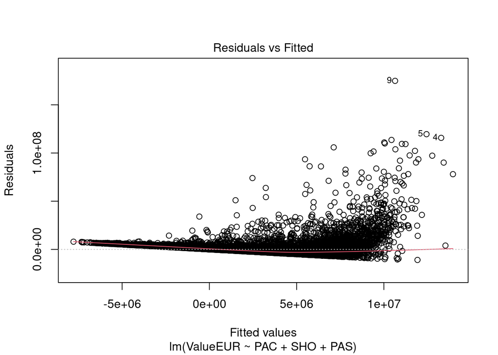

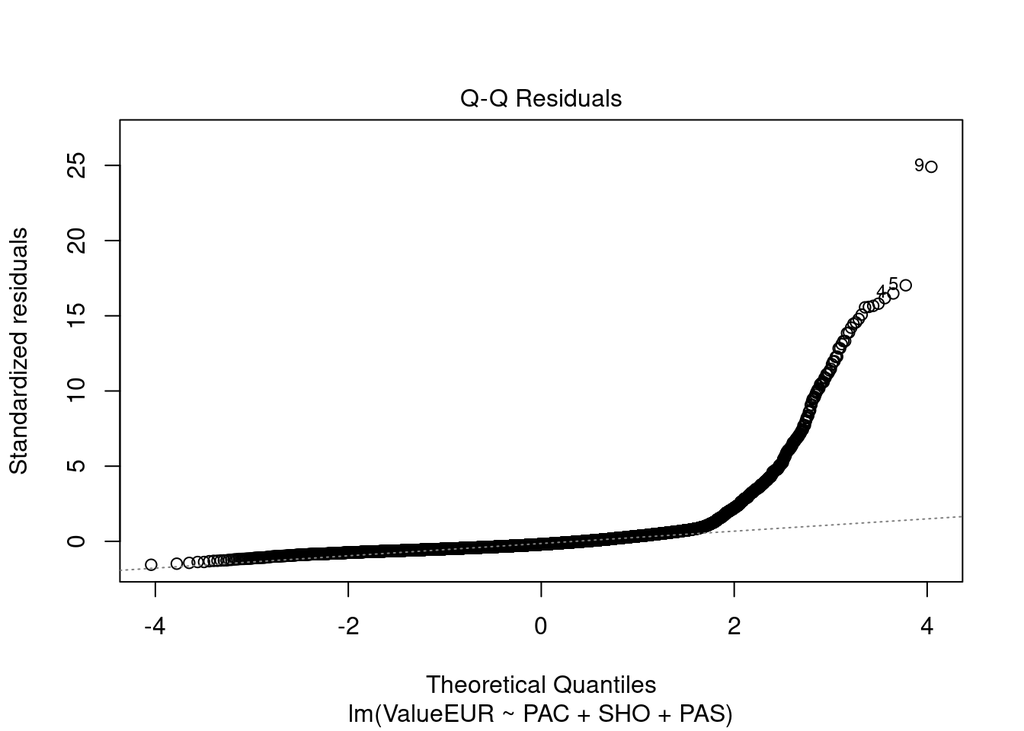

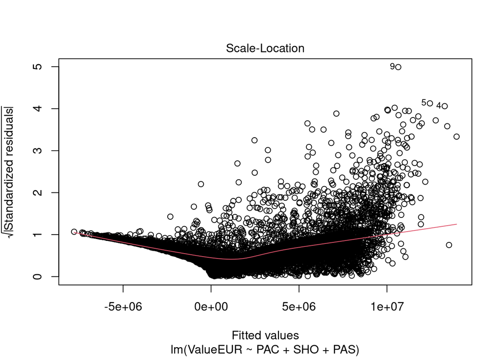

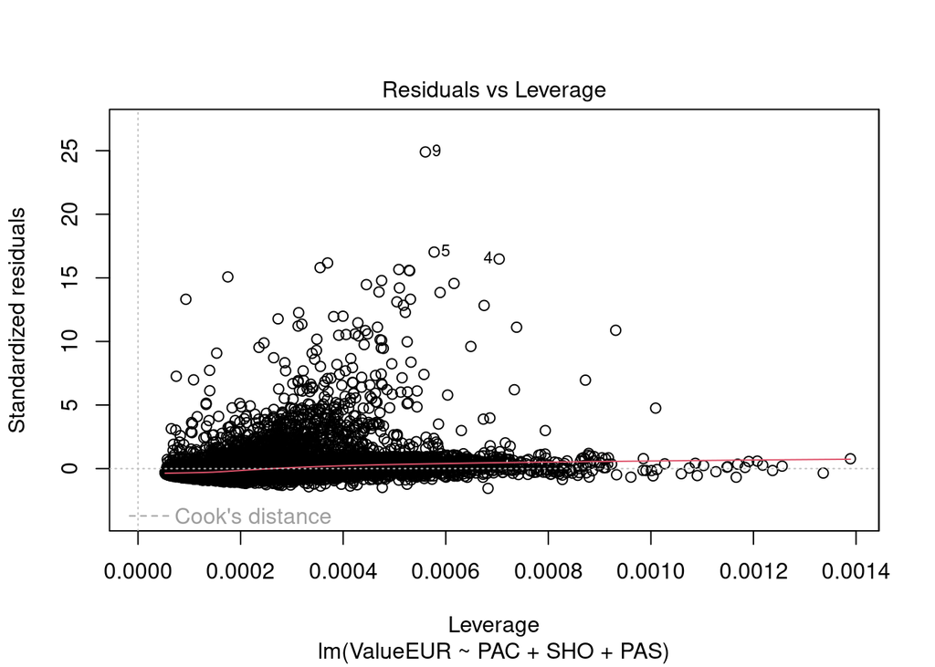

```r
value_model <- lm(ValueEUR ~ PAC + SHO + PAS, data = playerdata_clean)

plot(value_model)
```

```r
summary(value_model)
```

```
Call:
lm(formula = ValueEUR ~ PAC + SHO + PAS, data = playerdata_clean)

Residuals:
      Min        1Q    Median        3Q       Max
-10924233  -2924951  -1385212    952143 174859741

Coefficients:
             Estimate Std. Error t value Pr(>|t|)
(Intercept) -17932424     386399 -46.409   <2e-16 ***
PAC             70748       5114  13.833   <2e-16 ***
SHO              8058       5039   1.599     0.11
PAS            270358       6824  39.621   <2e-16 ***
---
Signif. codes:  0 '***' 0.001 '**' 0.01 '*' 0.05 '.' 0.1 ' ' 1

Residual standard error: 7023000 on 18975 degrees of freedom
Multiple R-squared:  0.1649,    Adjusted R-squared:  0.1648
F-statistic:  1249 on 3 and 18975 DF,  p-value: < 2.2e-16
```

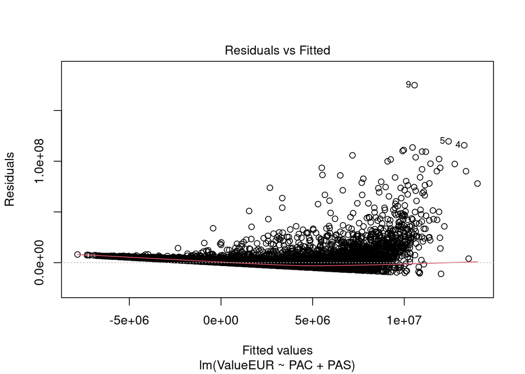

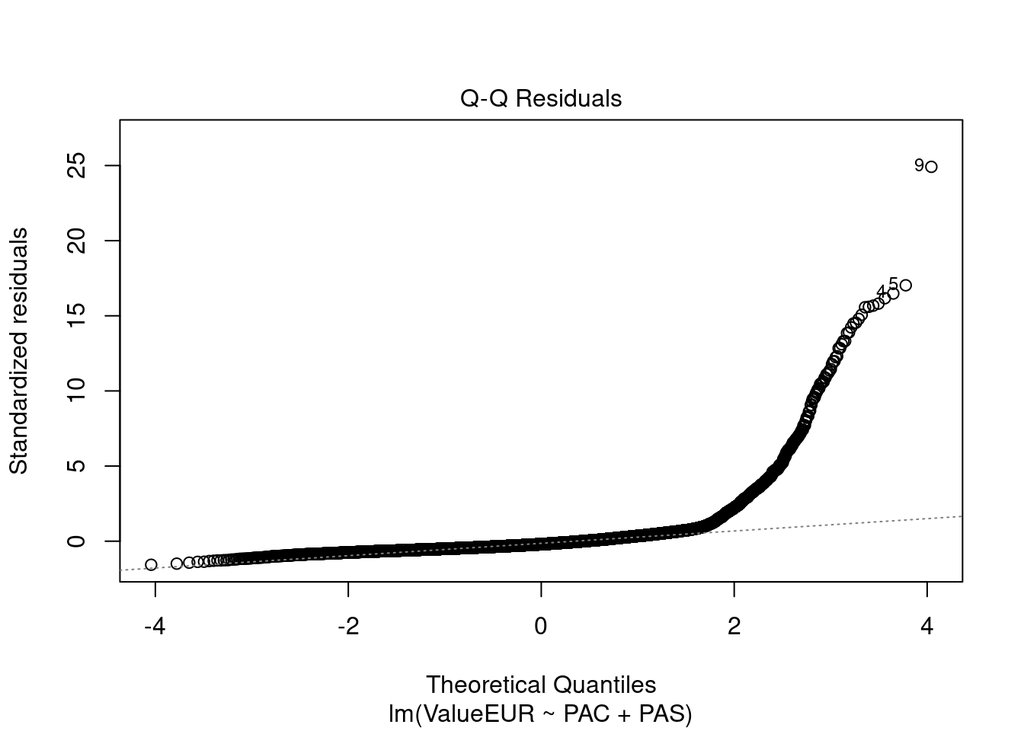

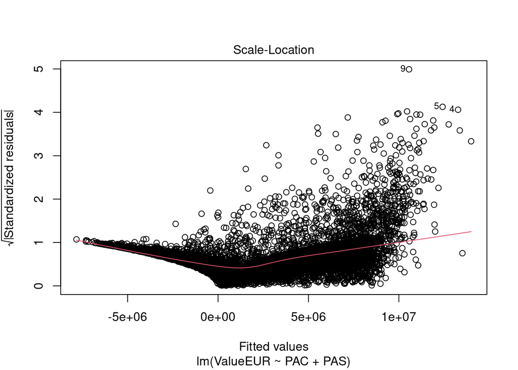

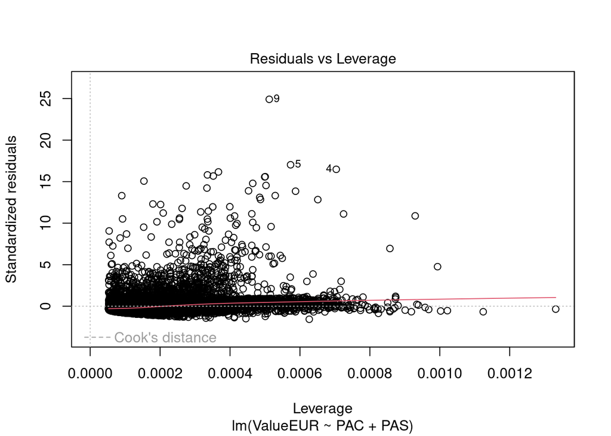

```r
value_model2 <- lm(ValueEUR ~ PAC + PAS, data = playerdata_clean)

plot(value_model2)
```

```r
summary(value_model2)
```

```
Call:
lm(formula = ValueEUR ~ PAC + PAS, data = playerdata_clean)

Residuals:
      Min        1Q    Median        3Q       Max
-11008139  -2927721  -1388317    962444 174937631

Coefficients:
             Estimate Std. Error t value Pr(>|t|)
(Intercept) -18003443     383854  -46.90   <2e-16 ***
PAC             72333       5018   14.41   <2e-16 ***
PAS            277203       5314   52.16   <2e-16 ***
---
Signif. codes:  0 '***' 0.001 '**' 0.01 '*' 0.05 '.' 0.1 ' ' 1

Residual standard error: 7024000 on 18976 degrees of freedom
Multiple R-squared:  0.1648,    Adjusted R-squared:  0.1647
F-statistic:  1872 on 2 and 18976 DF,  p-value: < 2.2e-16
```

## 6 Publication-quality graphs

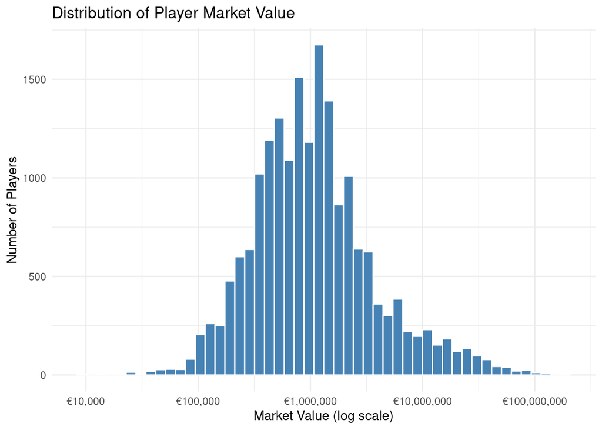

```r
ggplot(player_data, aes(x = ValueEUR)) +
  geom_histogram(bins = 50, fill = "steelblue", color = "white") +
  scale_x_log10(labels = scales::dollar_format(prefix = "€")) +
  labs(
    title = "Distribution of Player Market Value",
    x = "Market Value (log scale)",
    y = "Number of Players"
  ) +
  theme_minimal()
```

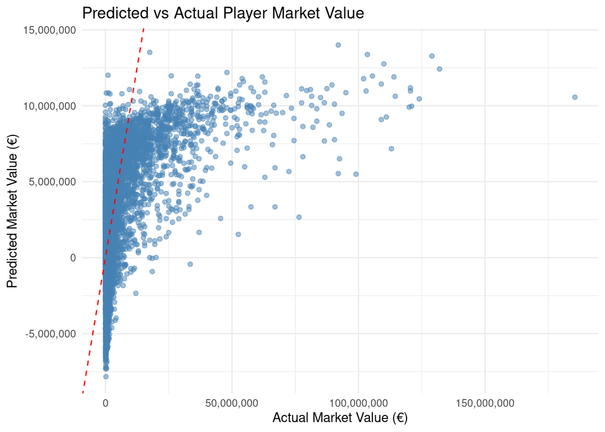

```r
# Add predicted values to the data
player_data$Predicted_Value <- predict(value_model2)

# Plot
library(scales)  # for comma format
ggplot(player_data, aes(x = ValueEUR, y = Predicted_Value)) +
  geom_point(alpha = 0.5, color = "steelblue") +
  geom_abline(slope = 1, intercept = 0, linetype = "dashed", color = "red") +
  labs(
    title = "Predicted vs Actual Player Market Value",
    x = "Actual Market Value (€)",
    y = "Predicted Market Value (€)"
  ) +
  scale_x_continuous(labels = comma) +
  scale_y_continuous(labels = comma) +
  theme_minimal()
```

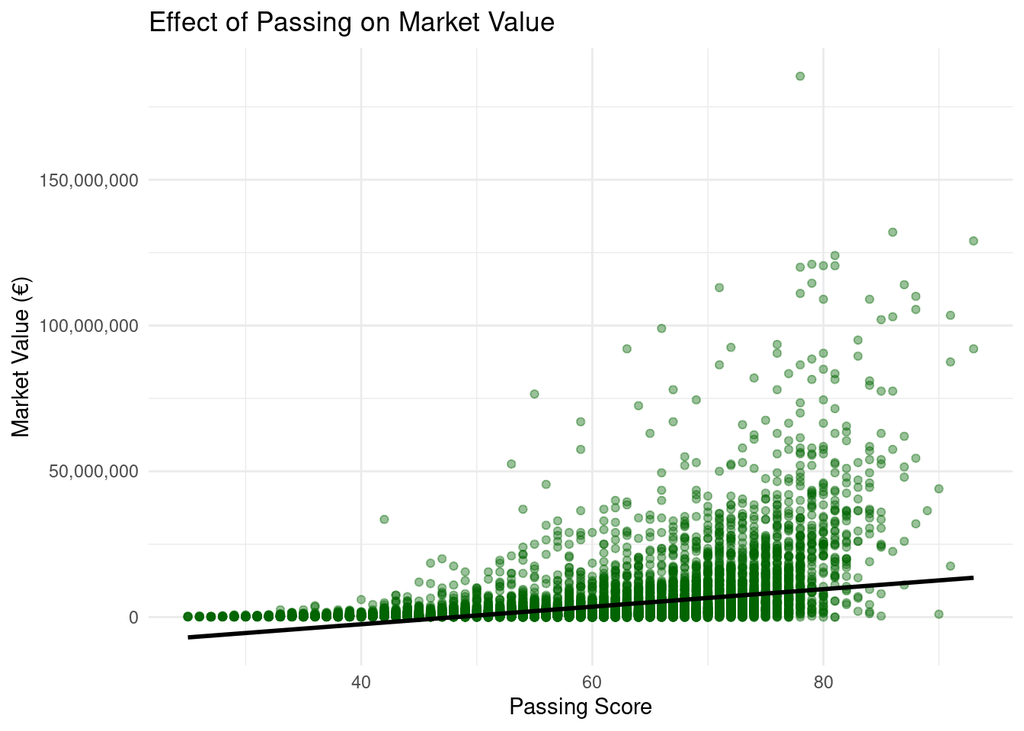

```r
ggplot(player_data, aes(x = PAS, y = ValueEUR)) +
  geom_point(alpha = 0.4, color = "darkgreen") +
  geom_smooth(method = "lm", se = FALSE, color = "black") +
  labs(
    title = "Effect of Passing on Market Value",
    x = "Passing Score",
    y = "Market Value (€)"
  ) +
  scale_y_continuous(labels = comma) +
  theme_minimal()
```

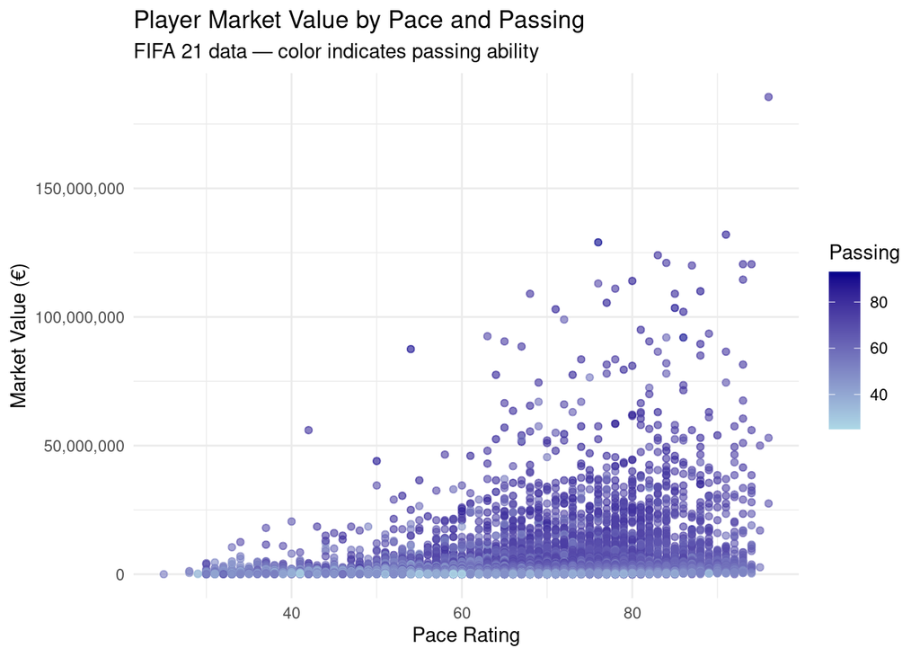

```r
ggplot(player_data, aes(x = PAC, y = ValueEUR, color = PAS)) +
  geom_point(alpha = 0.6) +
  scale_color_gradient(low = "lightblue", high = "darkblue") +
  scale_y_continuous(labels = scales::comma) +
  labs(
    title = "Player Market Value by Pace and Passing",
    subtitle = "FIFA 21 data — color indicates passing ability",
    x = "Pace Rating",
    y = "Market Value (€)",
    color = "Passing"
  ) +
  theme_minimal()
```

## 7 Brief discussion

This analysis explored how a soccer player’s individual attributes—specifically pace and passing—influence their market value. The dataset is quite large, containing over 18,000 players and many variables. Therefore, for the sake of my project I focused on just a few key attributes to keep the scope manageable and to demonstrate my ability to apply regression techniques. Using data from the FIFA 21 player dataset and a multiple linear regression model, I found that both pace and passing were statistically significant predictors of a player’s value, while shooting was not and was removed from the final model.

While the model does a good job of identifying general trends, there are of course limitations. For example, it doesn’t account for factors like age, club popularity, or player reputation—non-skill traits that can greatly influence market value in real-world scenarios. Future analyses could incorporate these variables for a more robust model.

Overall, this project demonstrates how statistical analysis can reveal the measurable impact of specific skills on player valuation in professional soccer, and highlights the usefulness of regression techniques in sports analytics.

## 8 Notes on rendering

When you use the **render** menu button, Rstudio only produces the first format (here, the html). To get everything, you can go to the the terminal tab (next to the console tab in bottom left window) and type

```
quarto render report_template.qmd
```

that will produce all listed formats (here, html, docx, and pdf).

## References

Bauer PC, Landesvatter C (2023) [Writing a reproducible paper with RStudio and Quarto](https://doi.org/10.31219/osf.io/ur4xn).